# Homework 3

Mingyang NI mn2813

**$1.$ Parallel Coordinates**

$(a)$ Draw a parallel coordinates plot of the data in “ManhattanCDResults.csv” in the data folder on CourseWorks. (Original data source and additional information about the data can be found here: https://cbcny.org/research/nyc-resident-feedback-survey-community-district-results). Your plot should have one line for each of the twelve Manhattan community districts in the dataset.

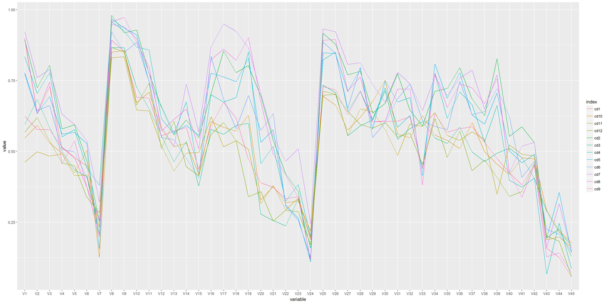

```r
library(GGally)
mydata <- read.csv(file="c:/Users/Mingyang/Desktop/ManhattanCDResults.csv", header=TRUE, sep=",")


mydata = mydata[,-2]
makenumber<- function(x){
  removesing<-sub("%", "", x)
  number=as.numeric(removesing)/100
}
for (col in colnames(mydata[,-1])){

    mydata[col] = sapply(mydata[col], makenumber)

}
MyData2=t(mydata)
MyData2=MyData2[-1,]
index=c('cd1','cd2','cd3','cd4','cd5','cd6','cd7','cd8','cd9','cd10','cd11','cd12')
index=as.vector(index)


MyData3=as.data.frame(MyData2)
indx <- sapply(MyData3, is.factor)
MyData3[indx] <- lapply(MyData3[indx], function(x) as.numeric(as.character(x)))
MyData3=cbind(MyData3,index)
MyData3=MyData3[,c(46,1:45)]
ggparcoord(MyData3,columns=c(2:46), groupColumn = "index",scale = "globalminmax")
```

$(b)$ Do there appear to be greater differences across *indicators* or across *community districts*? (In other words, are Manhattan community districts more alike or more different in how their citizens express their satisfaction with city life?

There appear to be greater differences across different indicators. As we can see from the plots, for all the community, they pretty much follow the same trend. Altough we can see a bit difference between lines for example at v1, this is not as dominant as the difference caused by indicators such as v8, v24.

$(c)$ Which indicators have wide distributions (great variety) in responses?

```r
sapply(MyData3[,2:45],var)
```

```
##          V1          V2          V3          V4          V5          V6
## 0.026830273 0.004945273 0.012713636 0.002586606 0.004590386 0.003937242
##          V7          V8          V9         V10         V11         V12
## 0.004767364 0.002945091 0.002147879 0.013542242 0.003871538 0.002678629
##         V13         V14         V15         V16         V17         V18
## 0.002847902 0.007368629 0.004858629 0.011762455 0.019562424 0.016078333
##         V19         V20         V21         V22         V23         V24
## 0.032899788 0.027307174 0.015765659 0.004728386 0.004252205 0.002235242
##         V25         V26         V27         V28         V29         V30
## 0.009024932 0.008766242 0.007369545 0.006975720 0.002386879 0.003884909
##         V31         V32         V33         V34         V35         V36
## 0.010546000 0.004403174 0.009268000 0.008424992 0.006844932 0.011813727
##         V37         V38         V39         V40         V41         V42
## 0.009396424 0.005252265 0.029868879 0.006622265 0.007126750 0.001898000
##         V43         V44
## 0.003845114 0.004088061
```

```r
max(sapply(MyData3[,2:45],var))
```

```
## [1] 0.03289979
```

We can observe that the results agree with out observation and the largest one comes from v19.

$(d)$ Does there appear to be a correlation between districts and overall satisfaction? In order words, do some districts report high satisfaction on many indicators and some report low satisfaction on many indicators or are the results more mixed? (Hint: a different color for each community district helps identify these trends).

Yes, there is. From the plot, we can easily see that the purple line is staying above the whole plot most of the time. However, the yellow and green lines are at the bottom more often.

**$2.$ Mosaic Plots**

Using the “Death2015.txt” data from the previous assignment, create a mosaic plot to identify whether `Age` is associated with `Place of Death`. Include only the top four `Age` categories. Treat `Age` as the independent variable and `Place of Death` as the dependent variable. (Hint: the dependent variable should be the last cut and it should be horizontal.) The labeling should be clear enough to identify what’s what, that is, “good enough,” not perfect. Do the variables appear to be associated? Describe briefly.

```r
library(vcd)
library(grid)
library(dplyr)
death = read.table('c:/Users/Mingyang/Desktop/Death2015.txt', nrows = 6896, header = TRUE, sep = "\t")
death %>%
  group_by(death$Ten.Year.Age.Groups) %>%
  summarise(no_rows = length(death$Ten.Year.Age.Groups))
```

```
## # A tibble: 12 x 2
##    `death$Ten.Year.Age.Groups` no_rows
##    <fct>                         <int>
##  1 < 1 year                       6896
##  2 1-4 years                      6896
##  3 15-24 years                    6896
##  4 25-34 years                    6896
##  5 35-44 years                    6896
##  6 45-54 years                    6896
##  7 5-14 years                     6896
##  8 55-64 years                    6896
##  9 65-74 years                    6896
## 10 75-84 years                    6896
## 11 85+ years                      6896
## 12 Not Stated                     6896
```

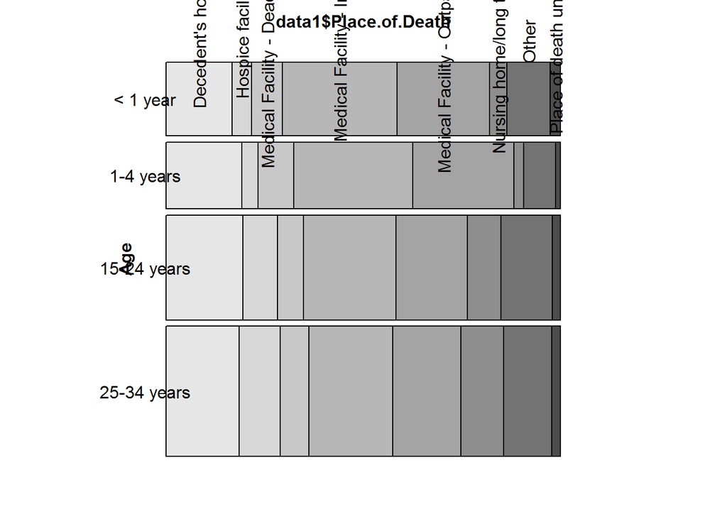

```r
data1 = death %>% group_by(`Ten.Year.Age.Groups`,`Place.of.Death`) %>%summarize(Freq=n())
top4 = levels(death$Ten.Year.Age.Groups)[1:4]
data1=data1[is.element(data1$Ten.Year.Age.Groups,top4),]
Age = factor(data1$Ten.Year.Age.Groups, levels = top4)
vcd::mosaic(data1$Place.of.Death ~ Age, data1,rot_labels = c(90, 0, 90, 0))
```

**$3.$ Time Series**

$(a)$ Use the `tidyquant` package to collect stock information on four stocks of your choosing. Create a line chart showing the closing price of the four stocks on the same graph, employing a different color for each stock.

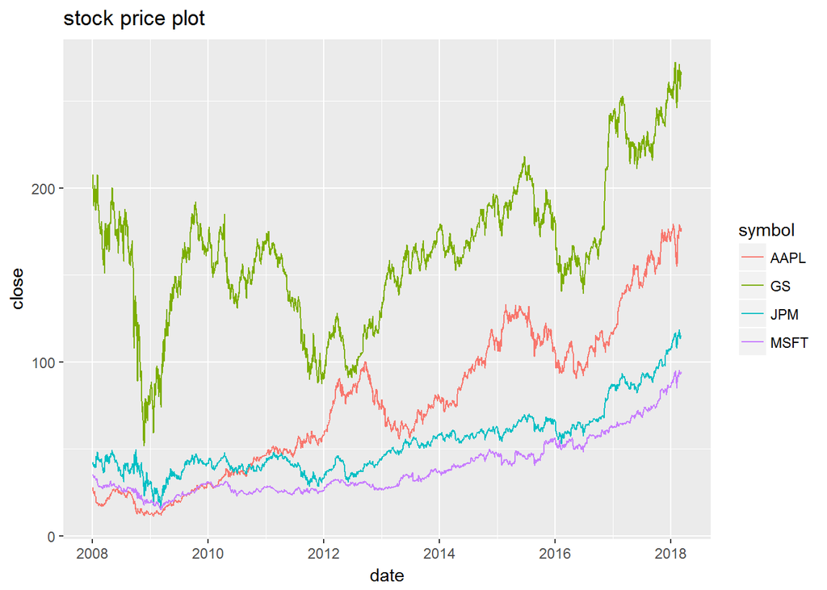

```r
library(tidyquant)
library(tidyverse)
stockname=c("MSFT", "AAPL", "GS","JPM")
stock = tq_get(stockname, get = "stock.prices")
ggplot(stock, aes(date, close, color = symbol)) + geom_line()+ggtitle("stock price plot")
```

$(b)$ Transform the data so each stock begins at 100 and replot. Do you learn anything new that wasn’t visible in part (a)?

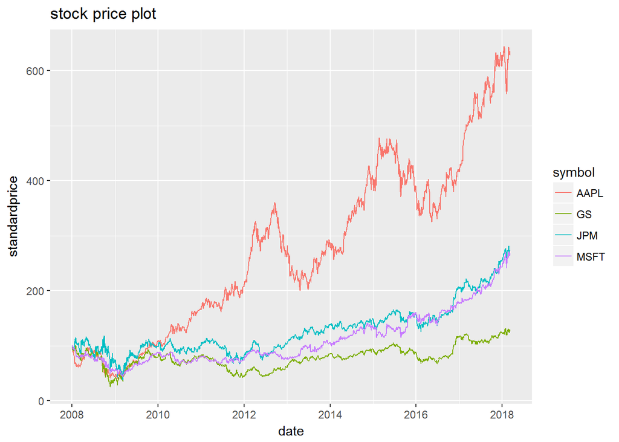

```r
stock= stock %>% group_by(symbol)
tidystock=stock%>%mutate(standardprice = 100*close/close[1]) %>% ungroup()
ggplot(tidystock, aes(date, standardprice, color = symbol)) + geom_line()+ggtitle("stock price plot")
```

Yes, this makes the relative growth more obvious. In parta, due to the difference in initial price, the growth of the stock price is not very abvious throughout the time horizon. After standardising the beginning price, the relative growth rate now is much more obvious. AAPL have the largest growth.

**$4.$ Missing Data**

For this question, explore the New York State Feb 2017 snow accumulation dataset available in the data folder on CourseWorks: “NY-snowfall-201702.csv”. The original data source is here: https://www.ncdc.noaa.gov/snow-and-ice/daily-snow/

$(a)$ Show missing patterns graphically.

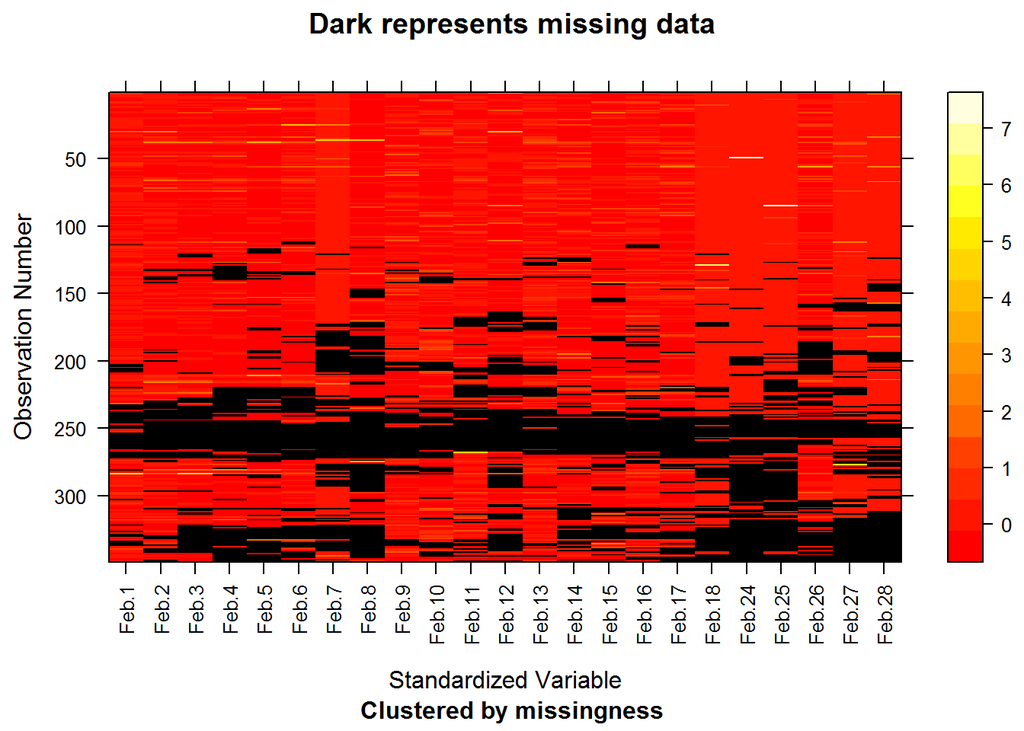

```r
MyData4 <- read.csv(file="c:/Users/Mingyang/Desktop/NY-snowfall-201702.csv", header=TRUE,skip=1, na.strings="M",check.name=FALSE,stringsAsFactors = FALSE)
snow=MyData4%>% select(`Feb 1`:`Feb 28`)%>%mutate_all(funs(ifelse(.=="T",.005,.)%>% as.numeric()))
library(mi)
x <- missing_data.frame(snow)
image(x)
```

$(b)$ Is the percent of missing values consistent across days of the month, or is there variety?

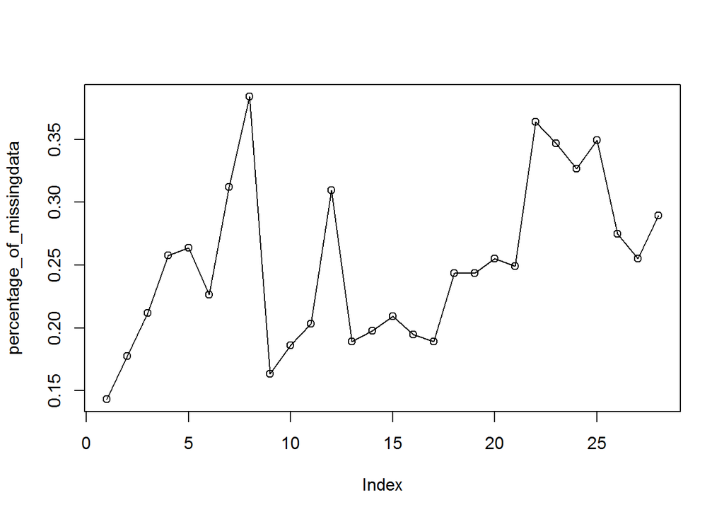

```r
percentage_of_missingdata=colSums(is.na(snow))/349
plot(percentage_of_missingdata,type="o")
```

It is not consistent across days of the month. We can see that certain dates will have a spike in the amount of missing data. However, this is only one month of data. The conclusion we draw here will not be very trustworthy.

$(c)$ Is the percent of missing values consistent across collection stations, or is there variety?

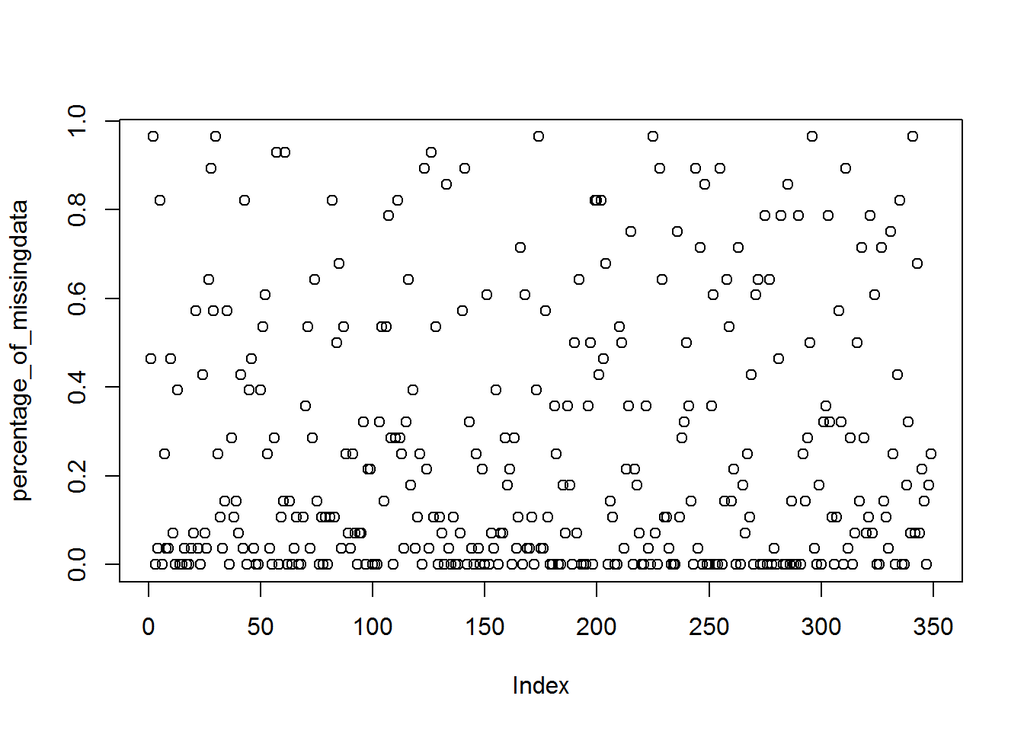

```r
percentage_of_missingdata=rowSums(is.na(snow))/28
plot(percentage_of_missingdata)
```

It is not consistent, we can see that certain station have a very low missing data while others have close to 1. It is obvious from the plot this is not consistent.

$(d)$ Is the daily average snowfall correlated with the daily missing values percent? On the basis of these results, what is your assessment of the reliability of the data to capture true snowfall patterns? In other words, based on what you’ve discovered, do you think that the missing data is highly problematic, or not?

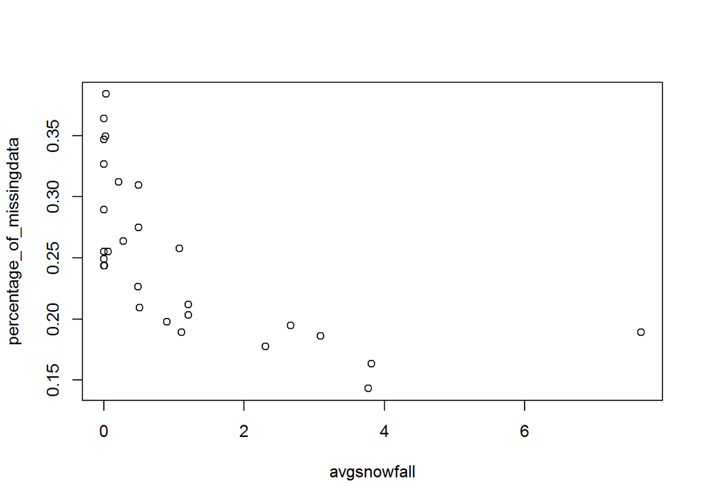

```r
percentage_of_missingdata=colSums(is.na(snow))/349
a=na.omit(snow)
avgsnowfall=colSums(a)/colSums(is.na(snow))

plot(avgsnowfall,percentage_of_missingdata)
```

This is not causing a lot of trouble. Most of the high percentage of missing data is concentrate on the low avgsnowfall which we do not care so much as compared to days with high snow fall.